# Part 3: Manuscript figures

```r
# Function to calculated proportion of sites/reach length for a scenario that
# is gained or lost when compared to the recent climate baseline. Dependent on
# two inputs: scenario predictions from augment() scenario character string name
# There are other required background inputs that are not changed that include:
# the elevation band df for the recent climate scenario as a baseline
# (elev_band_00rcnt) and the "elev_threshold_df" R df that holds the elevation
# band min/mid/max values and the factored bands column.
elev_band_proportion_fnx_temp_threshold <-
  function(augment_df, scenario_name, temp_threshold) {
  threshold_chr <- match.arg(as.character(temp_threshold), c("18", "19", "20"))

  elev_band_df <- augment_df |>
    # remove sf geometry
    st_drop_geometry() |>
    # grab the total reach length and number of reaches for each elevation band
    # filter to cold reaches
    filter(.fitted <= temp_threshold) |>
    # count reaches and sum up the length of stream within each elevation band
    group_by(elev_band = cut(v2elevm, breaks= seq(0, 750, elev_band_width_m)) ) |>
    reframe(clim_cond = scenario_name,
            n_sites = n(),
            reach_km = sum(Shape_Leng)/1000) |>
    # join the elevation band threshold df to this summary
    right_join(elev_threshold_df, by = c("elev_band") ) |>
    # add the baseline prediction data to this scenario's summary data
    left_join(select(
      switch(threshold_chr, `18` = elev_band_00rcnt18,
             `19` = elev_band_00rcnt19,
             `20` = elev_band_00rcnt20  ),
      elev_band_mid, n_sites_rcnt = n_sites, reach_km_rcnt = reach_km,
      n_sites_tot, reach_km_tot),
      by = c("elev_band_mid")) |>
    # calculate the relative stats based on the baseline scenario data
    mutate(siteprop_n = (n_sites/n_sites_rcnt)-1,
           siteprop_km = (reach_km/reach_km_rcnt)-1,
           siteprop_n_tot = (n_sites/n_sites_tot),
           siteprop_km_tot = (reach_km/reach_km_tot))
  return(elev_band_df)
}
```

```r
labels_for_FigureS <-
  c(futr = "Future",
    futrdam = "Future + dam",
    futrshade = "Future + shade",
    futrdamshade =  "Future + dam + shade",
    rcntdam = "Recent + dam",
    rcntshade = "Recent + shade",
    rcntdamshade = "Recent + dam + shade")
labels_for_FigureS_dummy <-
  c(futr = "Future",          dumb1 = "",                   dumb2 = "",
    futrdam = "Future + dam", futrshade = "Future + shade", futrdamshade = "Future + dam + shade",
    rcntdam = "Recent + dam", rcntshade = "Recent + shade", rcntdamshade = "Recent + dam + shade")


siteprop18_comboclimrest_df <-
  bind_rows(elev_band_proportion_fnx_temp_threshold(augm_rcntdam, "rcntdam", 18),
            elev_band_proportion_fnx_temp_threshold(augm_rcntshade, "rcntshade", 18),
            elev_band_proportion_fnx_temp_threshold(augm_rcntdamshade, "rcntdamshade", 18),
            elev_band_proportion_fnx_temp_threshold(augm_futr, "futr", 18),
            elev_band_proportion_fnx_temp_threshold(augm_futrdam, "futrdam", 18),
            elev_band_proportion_fnx_temp_threshold(augm_futrshade, "futrshade", 18),
            elev_band_proportion_fnx_temp_threshold(augm_futrdamshade, "futrdamshade", 18)) |>
  mutate(Scenario = factor(clim_cond,
                           levels = c("futr","futrdam","futrshade",
                                      "futrdamshade","rcntdam","rcntshade","rcntdamshade")))

siteprop19_comboclimrest_df <-
  bind_rows(elev_band_proportion_fnx_temp_threshold(augm_rcntdam, "rcntdam", 19),
            elev_band_proportion_fnx_temp_threshold(augm_rcntshade, "rcntshade", 19),
            elev_band_proportion_fnx_temp_threshold(augm_rcntdamshade, "rcntdamshade", 19),
            elev_band_proportion_fnx_temp_threshold(augm_futr, "futr", 19),
            elev_band_proportion_fnx_temp_threshold(augm_futrdam, "futrdam", 19),
            elev_band_proportion_fnx_temp_threshold(augm_futrshade, "futrshade", 19),
            elev_band_proportion_fnx_temp_threshold(augm_futrdamshade, "futrdamshade", 19)) |>
  mutate(Scenario = factor(clim_cond,
                           levels = c("futr","futrdam","futrshade",
                                      "futrdamshade","rcntdam","rcntshade","rcntdamshade")))

siteprop20_comboclimrest_df <-
  bind_rows(elev_band_proportion_fnx_temp_threshold(augm_rcntdam, "rcntdam", 20),
            elev_band_proportion_fnx_temp_threshold(augm_rcntshade, "rcntshade", 20),
            elev_band_proportion_fnx_temp_threshold(augm_rcntdamshade, "rcntdamshade", 20),
            elev_band_proportion_fnx_temp_threshold(augm_futr, "futr", 20),
            elev_band_proportion_fnx_temp_threshold(augm_futrdam, "futrdam", 20),
            elev_band_proportion_fnx_temp_threshold(augm_futrshade, "futrshade", 20),
            elev_band_proportion_fnx_temp_threshold(augm_futrdamshade, "futrdamshade", 20)) |>

  mutate(Scenario = factor(clim_cond,
                           levels = c("futr","dumb1","dumb2",
                                      "futrdam","futrshade","futrdamshade",
                                      "rcntdam","rcntshade","rcntdamshade")))
```

```r
siteprop18_comboclimrest_plot <-
   ggplot(data = filter(siteprop18_comboclimrest_df,
                        Scenario %in% c("rcntdam","rcntshade","rcntdamshade",
                                        "futr",
                                        "futrdam","futrshade","futrdamshade")),
          aes(x = elev_band_mid,
              color = Scenario,
              fill = Scenario,
              linetype = Scenario,
              linewidth = Scenario,
              y = siteprop_n)) +
   geom_hline(yintercept = 0, color = "grey50", linewidth = 0.75) +

   geom_smooth(se = FALSE, level = 0.95, method = "loess", formula = 'y~x') +

   theme_classic() +
   scale_linetype_manual(name = "Scenario",
                         values = c("dashed",
                                    "dotdash","dotdash","solid",
                                    "dotted","dotted","dotted"),
                         labels = labels_for_FigureS) +
   scale_linewidth_manual(name = "Scenario",
                          values = c(1, 1,1,1.5, 1,1,1),
                          labels = labels_for_FigureS) +
   scale_color_manual(name = "Scenario",
                      values = c('#b35806','#f1a340','#fee0b6','black',
                                 '#d8daeb','#998ec3','#542788'),
                      labels = labels_for_FigureS) +
   scale_fill_manual(name = "Scenario",
                     values = c('#b35806','#f1a340','#fee0b6','black',
                                '#d8daeb','#998ec3','#542788'),
                     labels = labels_for_FigureS) +
   scale_x_continuous(breaks = seq(0, 700, 100)) +
   coord_cartesian(ylim = c(-1, 10), xlim = c(0,725)) +
   ggbreak::scale_y_break(c(2, 2.5), scales = c(0.2,0.8) ) +
   theme(plot.title = element_markdown(),    # used for double line subtitle
         axis.title.x = element_blank(),
         legend.position = "none",
         plot.margin = margin(5.5, 5.5, 5.5, 5.5),
         legend.background = element_blank(),
         legend.key = element_blank(),
         legend.key.width = unit(0.5,"in"),  # increase width of legend keys
         legend.direction = "horizontal",
         legend.text.align = 0,
         plot.subtitle = element_markdown() # used for double line subtitle
   ) +
   guides(color = guide_legend(nrow = 4),
          fill = guide_legend(nrow = 4),
          linetype = guide_legend(nrow = 4),
          linewidth = guide_legend(nrow = 4)
   ) +
   labs(x = "Reach elevation (m)",
        title = "18\u00B0C threshold",
        y = "Proportion of coldwater habitat\n(reach length gained [+] or lost [-])")
# siteprop18_comboclimrest_plot
```

```r
siteprop19_comboclimrest_plot <-
   ggplot(data = filter(siteprop19_comboclimrest_df,
                        Scenario %in% c("rcntdam","rcntshade","rcntdamshade",
                                        "futr",
                                        "futrdam","futrshade","futrdamshade")),
          aes(x = elev_band_mid,
              color = Scenario,
              fill = Scenario,
              linetype = Scenario,
              linewidth = Scenario,
              y = siteprop_n)) +
   geom_hline(yintercept = 0, color = "grey50", linewidth = 0.75) +

   geom_smooth(se = FALSE, level = 0.95, method = "loess", formula = 'y~x') +

   theme_classic() +
   scale_linetype_manual(name = "Scenario",
                         values = c("dashed","dotdash","dotdash","solid",
                                    "dotted","dotted","dotted"),
                         labels = labels_for_FigureS) +
   scale_linewidth_manual(name = "Scenario",
                          values = c(1,1,1,1.5,1,1,1),
                          labels = labels_for_FigureS) +
   scale_color_manual(name = "Scenario",
                      values = c('#b35806','#f1a340','#fee0b6','black',
                                 '#d8daeb','#998ec3','#542788'),
                      labels = labels_for_FigureS) +
   scale_fill_manual(name = "Scenario",
                     values = c('#b35806','#f1a340','#fee0b6','black',
                                '#d8daeb','#998ec3','#542788'),
                     labels = labels_for_FigureS) +
   scale_x_continuous(breaks = seq(0, 700, 100)) +
   coord_cartesian(ylim = c(-1, 13), xlim = c(0,725)) +
   ggbreak::scale_y_break(c(2, 2.5), scales = c(0.2,0.8) ) +
   theme(plot.title = element_markdown(),    # used for double line subtitle
         axis.title.x = element_blank(),
         legend.position = "none",
         plot.margin = margin(5.5, 5.5, 5.5, 5.5),
         legend.background = element_blank(),
         legend.key = element_blank(),
         legend.key.width = unit(0.5,"in"),  # increase width of legend keys
         legend.direction = "horizontal",
         legend.text.align = 0,
         plot.subtitle = element_markdown() # used for double line subtitle
   ) +
   guides(color = guide_legend(nrow = 4),
          fill = guide_legend(nrow = 4),
          linetype = guide_legend(nrow = 4),
          linewidth = guide_legend(nrow = 4)
   ) +
   labs(x = "Reach elevation (m)",
        title = "19\u00B0C threshold",
        y = "Proportion of coldwater habitat\n(reach length gained [+] or lost [-])")
# siteprop19_comboclimrest_plot
```

```r
siteprop20_comboclimrest_plot <-
  ggplot(data = filter(siteprop20_comboclimrest_df,
                       Scenario %in% c("rcntdam","rcntshade","rcntdamshade",
                                       "futr",
                                       "futrdam","futrshade","futrdamshade")),
         aes(x = elev_band_mid,
             color = Scenario,
             fill = Scenario,
             linetype = Scenario,
             linewidth = Scenario,
             y = siteprop_n)) +
  geom_hline(yintercept = 0, color = "grey50", linewidth = 0.75) +

  geom_smooth(se = FALSE, level = 0.95, method = "loess", formula = 'y~x') +

  theme_classic() +
  scale_linetype_manual(name = "Scenario",
                        breaks = c("futr","dumb1","dumb2",
                                   "futrdam","futrshade","futrdamshade",
                                   "rcntdam","rcntshade","rcntdamshade"),
                        values = c("dashed",0,0,
                                   "dotdash","dotdash","solid",
                                   "dotted","dotted","dotted"),
                        labels = labels_for_FigureS_dummy, drop = FALSE, na.translate = FALSE) +
  scale_linewidth_manual(name = "Scenario",
                         breaks = c("futr","dumb1","dumb2",
                                    "futrdam","futrshade","futrdamshade",
                                    "rcntdam","rcntshade","rcntdamshade"),
                         values = c(1,0,0, 1,1,1.5, 1,1,1),
                         labels = labels_for_FigureS_dummy, drop = FALSE, na.translate = FALSE) +
  scale_color_manual(name = "Scenario",
                     breaks = c("futr","dumb1","dumb2",
                                "futrdam","futrshade","futrdamshade",
                                "rcntdam","rcntshade","rcntdamshade"),
                     values = c('#b35806',NA,NA,
                                '#f1a340','#fee0b6','black',
                                '#d8daeb','#998ec3','#542788'),
                     labels = labels_for_FigureS_dummy, drop = FALSE, na.translate = FALSE) +
  scale_fill_manual(name = "Scenario",
                    breaks = c("futr","dumb1","dumb2",
                               "futrdam","futrshade","futrdamshade",
                               "rcntdam","rcntshade","rcntdamshade"),
                    values = c('#b35806',NA,NA,
                               '#f1a340','#fee0b6','black',
                               '#d8daeb','#998ec3','#542788'),
                    labels = labels_for_FigureS_dummy, drop = FALSE, na.translate = FALSE) +
  scale_y_continuous(breaks = seq(-1, 2, 1),
                     labels = ~sub("-", "\u2212", .x)) +
  scale_x_continuous(breaks = seq(0, 700, 100)) +
  coord_cartesian(ylim = c(-1, 2), xlim = c(0,725)) +
  theme(legend.position = "bottom",
        plot.title = element_markdown(),    # used for double line subtitle
        plot.subtitle = element_markdown(), # used for double line subtitle
        plot.margin = margin(5.5, 5.5, 5.5, 5.5),
        legend.background = element_blank(),
        legend.key = element_blank(),
        legend.key.width = unit(0.5,"in"),  # increase width of legend keys
        legend.direction = "horizontal",
        legend.text.align = 0) +
  guides(color = guide_legend(ncol = 3, byrow = TRUE),
         fill = guide_legend(ncol = 3, byrow = TRUE),
         linetype = guide_legend(ncol = 3, byrow = TRUE),
         linewidth = guide_legend(ncol = 3, byrow = TRUE)) +
  labs(x = "Reach elevation (m)",
       title = "20\u00B0C threshold",
       y = "Proportion of coldwater habitat\n(reach length gained [+] or lost [-])")
# siteprop20_comboclimrest_plot
```

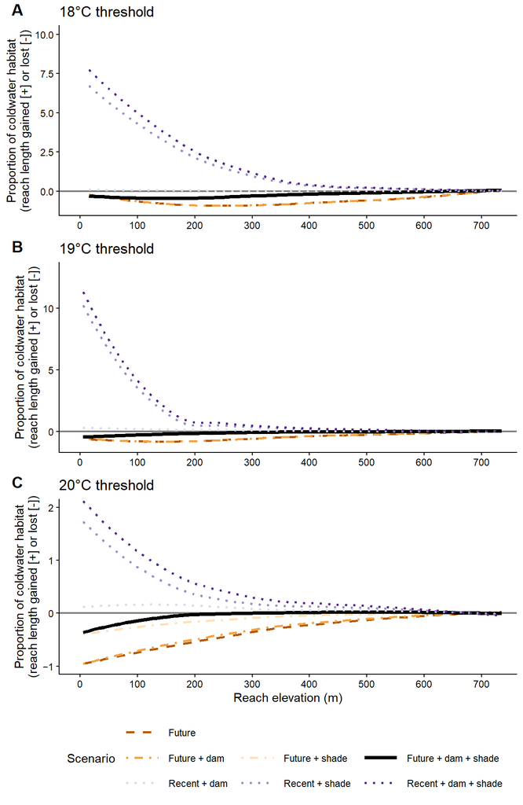

```r
temp_threshold_propreachkm_panel <-
  cowplot::plot_grid(
    siteprop18_comboclimrest_plot + ggbreak::scale_y_break(c(2, 2.5), scales = c(0.2,0.8) ),
    siteprop19_comboclimrest_plot + ggbreak::scale_y_break(c(2, 2.5), scales = c(0.2,0.8) ),
    siteprop20_comboclimrest_plot,
    ncol = 1, rel_heights = c(1,1,1.4),
    align = "v",
    axis = "lr",
    labels = c(" A"," B"," C"),
    label_y = c(1.01,1.01,1.01)
  ) +
  theme(plot.background = element_rect(fill = "white", color = NA))
temp_threshold_propreachkm_panel
```

```r
# ggsave(plot = temp_threshold_propreachkm_panel,
#        filename = paste0("../figures/",
#                          "FigureS3_coldwaterhabitat_propreachkm_allscenariocurves_PANEL.png"),
#        width = 6.5, height = 10, units = "in", dpi = 600)
#
# ggsave(plot = siteprop20_comboclimrest_plot,
#        filename = paste0("../figures/",
#                          "FigureS3_coldwaterhabitat_propreachkm_allscenariocurves_PANEL.eps"),
#        device = cairo_ps,
#        width = 6.5, height = 4, units = "in", dpi = 600)
```

## 7.4 Figure S4. Observed data temporal availability

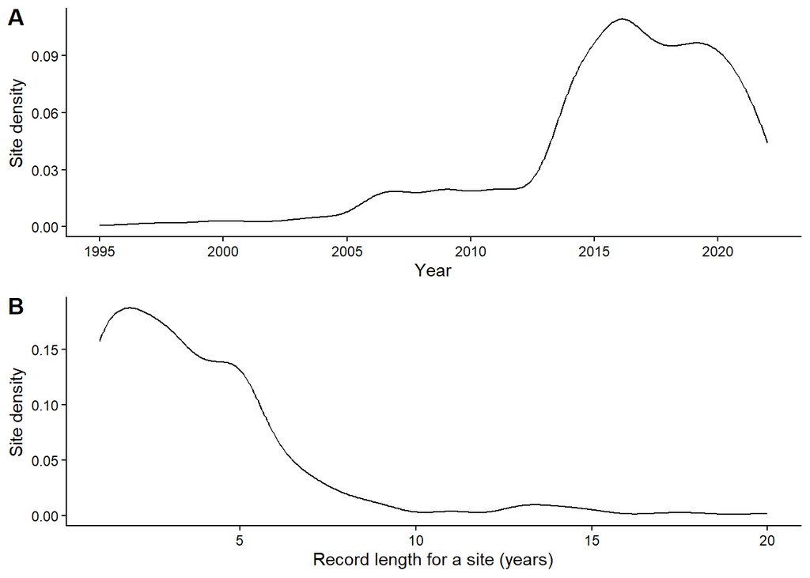

```r
# number of unique sites for july data
july_year_count_plot <-
  obs_df |> st_drop_geometry() |>
  reframe(.by = stn_id_num, year_n = n()) |>
  ggplot(aes(x = year_n)) +
  geom_density() +
  theme_classic() +
  scale_x_continuous(n.breaks = 7) +
  labs(x = "Record length for a site (years)",
       y = "Site density")

# plot density of temperature data for years used in model fit
data_density_by_year_plot <-
  ggplot(data = obs_df) +
  geom_density(aes(x = smpl_year)) +
  theme_classic() +
  scale_x_continuous(n.breaks = 7) +
  labs(x = "Year", y = "Site density")

(observation_data_panel_plot <-
    cowplot::plot_grid(data_density_by_year_plot, july_year_count_plot,
                       nrow = 2,labels = c("A","B")) )
```

```r
# ggsave(plot = observation_data_panel_plot,
#        filename = "../figures/FigureS4_obs_data_panel_plot.png",
#        width = 6.5, height = 6.5, units = "in", dpi = 1200)
```

## 7.5 Figure S5. Observed data correlation plot

```r
corrplot_df <- obs_df |> st_drop_geometry() |>
  select(ssnid, stn_id_num, smpl_year, starts_with("WT_"),
         AreaKm2, dJLtavg, BFIc, CPY100x, v2elevm, NIDDENw)

# function to plot correlation coefficients for FWS formatting/publication
my_cor <- function(data, mapping, ...){
  x <- rlang::eval_tidy(mapping$x, data)
  y <- rlang::eval_tidy(mapping$y, data)
  # convert to numeric if needed
  x <- as.numeric(x)
  y <- as.numeric(y)
  corr <- round(cor(x, y, use = "complete.obs"), 2)
  ggplot() +
    annotate("text", x = 0.5, y = 0.5,
             label = paste0("Corr:\n",corr), size = 4) +
    theme_void()
}
```

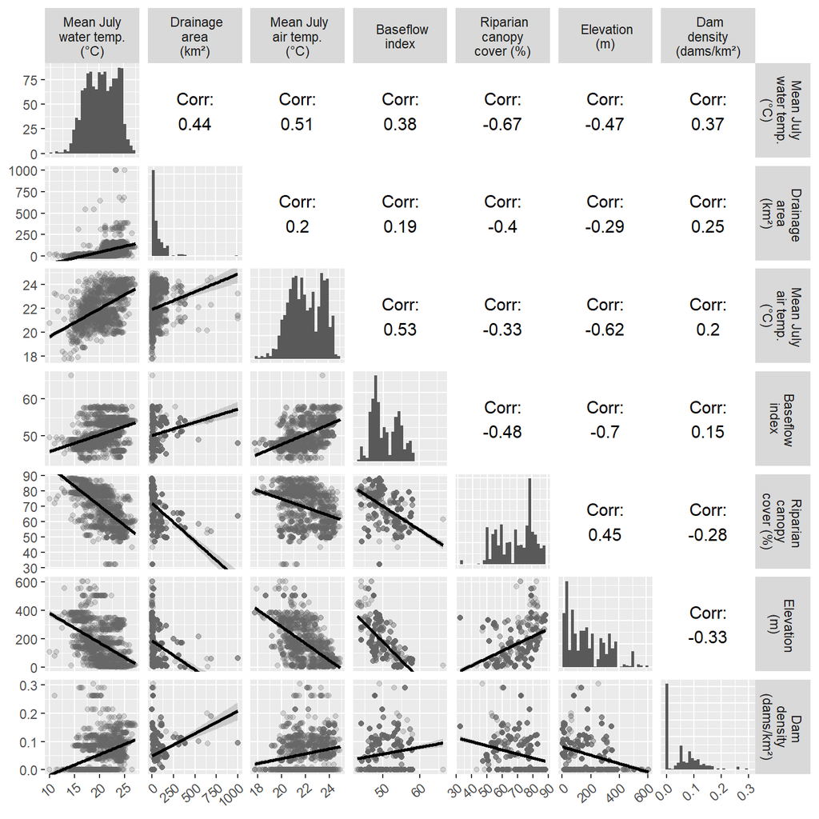

```r
corrplot <- corrplot_df |>
   select(WT_avg, AreaKm2, dJLtavg, BFIc, CPY100x, v2elevm, NIDDENw) |>
   ggpairs(
     columnLabels =
       c("Mean July\nwater temp.\n(\u00B0C)",
         " Drainage\narea\n(km\u00b2)",
         " Mean July\nair temp.\n(\u00B0C)",
         " Baseflow\nindex",
         " Riparian\ncanopy\ncover (%)",
         " Elevation\n(m)",
         " Dam\ndensity\n(dams/km\u00b2)" ),
     upper = list(continuous = wrap(my_cor)),  # show correlation coefficients
     # scatterplots with smooth lines
     lower = list(continuous = GGally::wrap("smooth", colour = "grey40",
                                            alpha = 0.25, size = 1.5)),
     diag = list(continuous = "barDiag")) +              # histograms on diagonal
     theme(axis.text.x = element_text(angle = 40, hjust = 1))
corrplot
```

```r
# ggsave(corrplot, width = 7.5, height = 7.5, dpi = 1200, units = "in",
#        filename = "../figures/FigureS5_modelvariable_correlationpot.png")
```

## 7.6 Figure S6. Covariate boxplots

```r
cov_df <-
  bind_rows(obs_df |> st_drop_geometry() |> mutate(Data = "obs") |>
              select(Data, AreaKm2, dJLtavg, BFIc, CPY100x, v2elevm, NIDDENw) |>
              pivot_longer(cols = !Data, names_to = "Covariate",values_to = "value"),
            preds_df |> st_drop_geometry() |> mutate(Data = "preds") |>
              select(Data, AreaKm2, dJLtavg, BFIc, CPY100x, v2elevm, NIDDENw) |>
              pivot_longer(cols = !Data, names_to = "Covariate",values_to = "value")) |>
  mutate(Covariate = factor(Covariate,
                            levels = c("BFIc",
                                       "CPY100x",
                                       "NIDDENw",
                                       "AreaKm2",
                                       "v2elevm",
                                       "dJLtavg"
                            ),
                            labels = c("Baseflow Index (BFI)",
                                       "Canopy cover (%)",
                                       "Dam density (dams/km\u00b2)",
                                       "Drainage Area (km\u00b2)",
                                       "Elevation (m a.s.l.)",
                                       "Mean July air temperature (\u00B0C)"
                            ) ) ) |>
  mutate(across(where(is.numeric), ~ pmax(.x, 0.000001)))
```

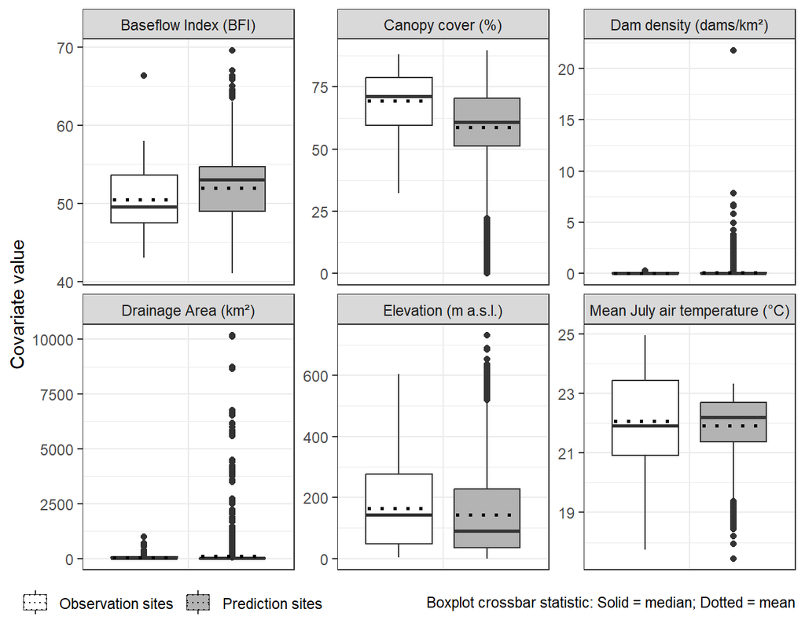

```r
(cov_summary_plot <-
   ggplot(data = cov_df, aes(x = Covariate, fill = Data, y = value)) +
   geom_boxplot(position = position_dodge(width = 1),
                median.linewidth = 1) +
   stat_summary(fun = mean, geom = "crossbar", width = 0.7, size = 0.4,
                position = position_dodge(width = 1), linetype = "dotted") +
   theme_bw() +
   scale_fill_manual(breaks = c("obs", "preds"),
                      values = c("white","grey70"),
                      labels = c("Observation sites","Prediction sites")) +
   theme(legend.position = "inside", legend.position.inside = c(0.125,-0.062),
         legend.direction = "horizontal", legend.background = element_blank(),
         legend.title = element_blank()) +
   labs(y = "Covariate value",
        caption = "\nBoxplot crossbar statistic: Solid = median; Dotted = mean") +
   facet_wrap(~ Covariate, scales = "free") +
   theme(axis.title.x = element_blank(),
         axis.text.x = element_blank(),
         axis.ticks.x = element_blank()) +
   ggh4x::facetted_pos_scales(
     y = list(Covariate == "Dam density" ~ scale_y_log10(labels = scales::label_number()),
              Covariate == "Drainage Area" ~ scale_y_log10(labels = scales::label_number()) )
   )
)
```

```r
# ggsave(plot = cov_summary_plot,
#        filename = "../figures/FigureS6_covariate_summary_boxplot.png",
#        width = 6.5,height = 5, dpi = 600, units = "in")
#
# ggsave(plot = cov_summary_plot,
#        filename = "../figures/FigureSXY_covariate_summary_boxplot.eps",
#        device = cairo_ps,
#        width = 6.5,height = 5, dpi = 600, units = "in")
```

## 7.7 Table S1. Covariate Summary Statistics Table

```r
preds_cov_df <- preds_df |>
  st_drop_geometry() |>
  select(AreaKm2, dJLtavg, BFIc, CPY100x, v2elevm, NIDDENw) |>
  summarise(
    across(
      where(is.numeric),
      list(
        mean   = ~ mean(.x, na.rm = TRUE),
        median = ~ median(.x, na.rm = TRUE),
        min    = ~ min(.x, na.rm = TRUE),
        max    = ~ max(.x, na.rm = TRUE),
        q1     = ~ quantile(.x, 0.25, na.rm = TRUE, names = FALSE),
        q3     = ~ quantile(.x, 0.75, na.rm = TRUE, names = FALSE)
      ),
      .names = "{.col}_{.fn}"
    )
  ) |>
  pivot_longer(everything(), names_to  = c("variable", "stat"),
               names_sep = "_", values_to = "value" ) |>
  pivot_wider(names_from  = stat, values_from = value )|>
  mutate(Data = "Prediction sites")
```

```r
obs_cov_df <- obs_df |> st_drop_geometry() |>
  select(AreaKm2, dJLtavg, BFIc, CPY100x, v2elevm, NIDDENw) |>
  summarise(
    across(
      where(is.numeric),
      list(
        mean   = ~ mean(.x, na.rm = TRUE),
        median = ~ median(.x, na.rm = TRUE),
        min    = ~ min(.x, na.rm = TRUE),
        max    = ~ max(.x, na.rm = TRUE),
        q1     = ~ quantile(.x, 0.25, na.rm = TRUE, names = FALSE),
        q3     = ~ quantile(.x, 0.75, na.rm = TRUE, names = FALSE)
      ),
      .names = "{.col}_{.fn}"
    )
  ) |>
  pivot_longer(everything(), names_to  = c("variable", "stat"),
               names_sep = "_", values_to = "value" ) |>
  pivot_wider(names_from  = stat, values_from = value ) |>
  mutate(Data = "Observation sites")
```

```r
cov_summary_df <- bind_rows(obs_cov_df, preds_cov_df) |>
  mutate(Covariate = factor(variable,
                            levels = c("AreaKm2","BFIc","CPY100x","dJLtavg","NIDDENw","v2elevm"),
                            labels = c("Drainage Area", "Baseflow Index (BFI)",
                                       "Canopy cover", "Mean July air temperature",
                                       "Dam density", "Elevation")),
         units = factor(variable,
                        levels = c("AreaKm2","BFIc","CPY100x","dJLtavg","NIDDENw","v2elevm"),
                        labels = c("km\u00b2", "unitless (0-100)", "%", "\u00B0C",
                                   "dams per km\u00b2", "meters"))  ) |>
  mutate(across(where(is.numeric), ~ sprintf("%.2f", .x))) |>
  arrange(Covariate, Data) |>
  select(Covariate, units, Data, min, q1, mean, median, q3, max)

DT::datatable(cov_summary_df)
```

|  | Covariate | units | Data | min | q1 | mean | median | q3 | max |
| --- | --- | --- | --- | --- | --- | --- | --- | --- | --- |
| 1 | Drainage Area | km² | Observation sites | 0.32 | 4.60 | 54.90 | 20.02 | 67.45 | 999.18 |
| 2 | Drainage Area | km² | Prediction sites | 0.00 | 1.90 | 117.96 | 6.40 | 26.26 | 10181.88 |
| 3 | Baseflow Index (BFI) | unitless (0-100) | Observation sites | 43.00 | 47.49 | 50.50 | 49.52 | 53.58 | 66.30 |
| 4 | Baseflow Index (BFI) | unitless (0-100) | Prediction sites | 41.00 | 49.00 | 51.91 | 53.00 | 54.64 | 69.58 |
| 5 | Canopy cover | % | Observation sites | 32.38 | 59.52 | 69.36 | 71.10 | 78.73 | 88.20 |
| 6 | Canopy cover | % | Prediction sites | 0.00 | 51.17 | 58.68 | 60.75 | 70.47 | 89.71 |
| 7 | Mean July air temperature | °C | Observation sites | 17.76 | 20.91 | 22.07 | 21.92 | 23.43 | 24.95 |
| 8 | Mean July air temperature | °C | Prediction sites | 17.46 | 21.37 | 21.92 | 22.21 | 22.70 | 23.33 |
| 9 | Dam density | dams per km² | Observation sites | 0.00 | 0.00 | 0.06 | 0.05 | 0.09 | 0.30 |
| 10 | Dam density | dams per km² | Prediction sites | 0.00 | 0.00 | 0.09 | 0.00 | 0.10 | 21.79 |

[output cut: 2 more lines]

```r
write_csv(cov_summary_df, "../tables/TableS1_covariate_summary_stats.csv")
```

**Note:** Mean July air temperature for predictions can have a lower maximum than the observation data set because the prediction values are *average* values across the 1990-2022 period rather than a single year’s mean July air temperature. Consequently, that single year could potentially be higher than the historical average air temperature at a reach. This may come as a surprise on initial glance at the table because it’s generally expected that the predictions cover a wider range of values across the study extent, which is the case for all the other covaraites.

## 7.8 Figure S7. Recent climate (1990-2022) temperature maps

```r
# generate standardized color palette
temp_palette <-
  colorRampPalette(rev(RColorBrewer::brewer.pal(10, "RdYlBu") ))
sc <- scale_colour_gradientn(colors = temp_palette(100),
                             limits=c(10, 36),
                             guide = guide_colorbar(
                               title = "Temperature (\u00B0C)",
                               direction = "horizontal",
                               title.position = "top",
                               label.position = "bottom",
                               barwidth  = unit(6, "cm"),
                               barheight = unit(4, "mm"),
                               ticks = TRUE),
                             na.value = "black")
```

```r
# Create the main map of Massachusetts with a Cividis discrete color palette
main_map_scenario <- ggplot() +
  # Add the state boundary
  geom_sf(data = ma_state_boundary, fill = NA, color = "grey20", linewidth = 0.5) +

  # add Connecticut and Merrimack Rivers
  geom_sf(data = filter(ma_streams_sf, TotDASqKM > 5000),
          color = "grey30", linewidth = 1, lineend = "round") +
  geom_text(aes(x = -8080000, y = 5291000 , hjust = 1),
            label  = "Connecticut River", size = 3) +
  geom_text(aes(x = -8020000, y = 5291000, hjust = 0),
            label  = "Merrimack River", size = 3) +

  # add the observation sites
  geom_sf(data = obs_df,
          color = "black", shape = 1,
          stroke = 0.2, size = 2) +

  # Add North Arrow
  annotation_north_arrow(
    location = "tr",       # Top right location
    which_north = "true",
    pad_x = unit(0.2, "in"), # Padding from the edge
    pad_y = unit(0.2, "in"),
    style = north_arrow_fancy_orienteering # A decorative style
  ) +

  # Add Scale Bar
  annotation_scale(
    location = "tr",       # Bottom left location
    bar_cols = c("black", "white"),
    width_hint = 0.18,      # Relative width of the scale bar (30% of map width)
    pad_y = unit(3, "cm")
  ) +

  # Set map coordinates
  coord_sf(crs = 3857) +
  theme_void() +
  theme(axis.title = element_blank(),
        legend.position = "inside", legend.position.inside = c(0.2,0.45),
        legend.background = element_rect(fill = "white"),
        plot.background = element_rect(fill = "white")
        )
```

```r
scenario_rcnt_ggplot <-
  ggdraw(main_map_scenario +
           geom_sf(data = filter(ma_streams_sf, TotDASqKM < 2550 & Tw_rcnt < 34),
                   aes(color = Tw_rcnt, linewidth = TotDASqKM),
                   lineend = "round") +
           coord_sf(crs = 3857,
                    xlim = c(map_extent[1], map_extent[3]),
                    ylim = c(map_extent[2]-50000, map_extent[4]),
                    expand = FALSE)  +
           scale_linewidth(range = c(0.25, 1.25), guide = "none") +
           labs(title = "    Recent climate: air temperature averaged across 1990-2022"
           ) +
           sc
  )  +
  draw_plot(NA_map_ggplot, x = 0.02, y = -0.03, width = 0.35, height = 0.4) +
  draw_plot(ne_inset, x = 0.3, y = 0, width = 0.35, height = 0.4)

# ggsave(plot = scenario_rcnt_ggplot,
#        filename = "../figures/FigureSXX_temp_map_rcnt.png",
#        width = 6.5,height = 5, dpi = 600, units = "in")
```

```r
scenario_rcntdam_ggplot <-
  ggdraw(main_map_scenario +
           geom_sf(data = filter(ma_streams_sf, TotDASqKM < 2550 & Tw_rcnt < 34),
                   aes(color = Tw_rcntdam, linewidth = TotDASqKM),
                   lineend = "round") +
           coord_sf(crs = 3857,
                    xlim = c(map_extent[1], map_extent[3]),
                    ylim = c(map_extent[2]-50000, map_extent[4]),
                    expand = FALSE)  +
           scale_linewidth(range = c(0.25, 1.25), guide = "none") +
           labs(title = "    Recent climate + dam removal (remove 1 dam/10km\u00b2)"
           ) +
           sc
  )  +
  draw_plot(NA_map_ggplot, x = 0.02, y = -0.03, width = 0.35, height = 0.4) +
  draw_plot(ne_inset, x = 0.3, y = 0, width = 0.35, height = 0.4)

# ggsave(plot = scenario_rcntdam_ggplot,
#        filename = "../figures/FigureSXX_temp_map_rcntdam.png",
#        width = 6.5,height = 5, dpi = 600, units = "in")
```

```r
scenario_rcntshade_ggplot <-
  ggdraw(main_map_scenario +
           geom_sf(data = filter(ma_streams_sf, TotDASqKM < 2550 & Tw_rcnt < 34),
                   aes(color = Tw_rcntshade, linewidth = TotDASqKM),
                   lineend = "round") +
           coord_sf(crs = 3857,
                    xlim = c(map_extent[1], map_extent[3]),
                    ylim = c(map_extent[2]-50000, map_extent[4]),
                    expand = FALSE)  +
           scale_linewidth(range = c(0.25, 1.25), guide = "none") +
           labs(title = "    Recent climate + restored riparian shade (+10% reach shade)"
           ) +
           sc
  )  +
  draw_plot(NA_map_ggplot, x = 0.02, y = -0.03, width = 0.35, height = 0.4) +
  draw_plot(ne_inset, x = 0.3, y = 0, width = 0.35, height = 0.4)

# ggsave(plot = scenario_rcntshade_ggplot,
#        filename = "../figures/FigureSXX_temp_map_rcntshade.png",
#        width = 6.5,height = 5, dpi = 600, units = "in")
```

```r
scenario_damshade_ggplot <-
  ggdraw(main_map_scenario +
           geom_sf(data = filter(ma_streams_sf, TotDASqKM < 2550 & Tw_rcnt < 34),
                   aes(color = Tw_rcntdamshade, linewidth = TotDASqKM),
                   lineend = "round") +
           coord_sf(crs = 3857,
                    xlim = c(map_extent[1], map_extent[3]),
                    ylim = c(map_extent[2]-50000, map_extent[4]),
                    expand = FALSE)  +
           scale_linewidth(range = c(0.25, 1.25), guide = "none") +
           labs(title = "    Recent climate + dam removal + shade restoration"
           ) +
           sc
  )  +
  draw_plot(NA_map_ggplot, x = 0.02, y = -0.03, width = 0.35, height = 0.4) +
  draw_plot(ne_inset, x = 0.3, y = 0, width = 0.35, height = 0.4)

# ggsave(plot = scenario_damshade_ggplot,
#        filename = "../figures/FigureSXX_temp_map_rcntdamshade.png",
#        width = 6.5,height = 5, dpi = 600, units = "in")
```

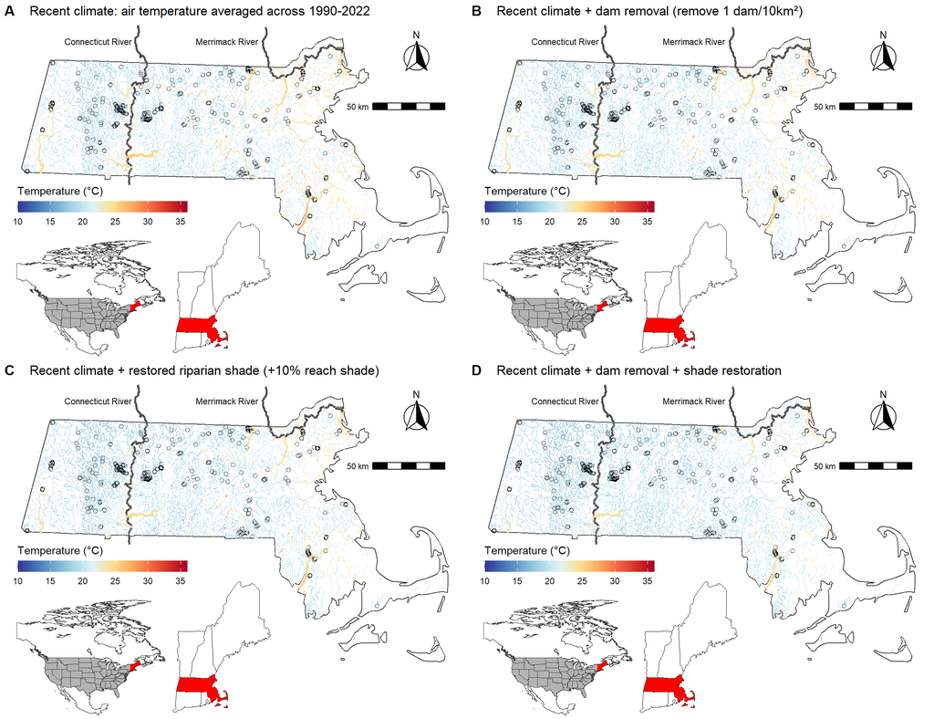

```r
recent_scenario_maps <-
  cowplot::plot_grid(scenario_rcnt_ggplot, scenario_rcntdam_ggplot,
                   scenario_rcntshade_ggplot, scenario_damshade_ggplot,
                   labels = c("A","B","C","D"),
                   nrow = 2, ncol = 2,
                   label_x = -0.001) +
  theme(plot.background = element_rect(fill = "white",color = NA))
recent_scenario_maps
```

```r
# ggsave(plot = recent_scenario_maps,
#        filename = "../figures/FigureS7_temp_maps_recent_climate.png",
#        width = 13, height = 10, dpi = 600, units = "in")
```